# Key Performance Indicators Example

Tim Essam | SI

2021-01-12

```r
# Setup knitr defaults and folder paths
  knitr::opts_chunk$set(echo = TRUE, message = FALSE, warning = FALSE, out.width = '100%')

  pub_images <- "public_images"

# Set up caption object
  caption <- paste0("Source: Testing data from glitr package | Created on: ", Sys.Date())

# Add libraries needed
  library(tidyverse)
  library(scales)
  library(glitr)
  library(here)
  library(patchwork)
```

### Showing Magnitude (Bar Charts)

Bar graphs are one of the most effective ways of comparing the magnitudes of a metric aross numerous categories. Sorting the bars based on the magnitude (not alphabetically) helps the reader make quick comparisons. Highlighting bars above a given threshold can help distinguish different classes of categories.

When munging the hts data for the bar graph, make use of the `forcats::fct_reorder()` or `tidytext::reorder_within()` functions to help with sorting bars and/or facets. If you try to plot without setting the primepartner as an ordered factor, you will get a plot like the one below.

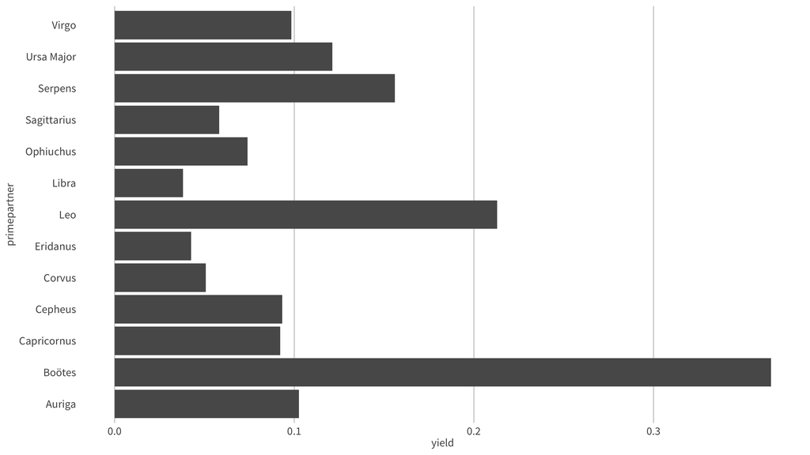

Unsorted bar graph

```r
# Munge the hts data down to testing yields for a given year
  hts_bar <-
    hts %>%
    filter(period == "FY50", period_type == "cumulative") %>%
    group_by(indicator, primepartner) %>%
    summarise(total = sum(value, na.rm = TRUE)) %>%
    ungroup() %>%
    spread(indicator, total) %>%
    mutate(yield = (HTS_TST_POS / HTS_TST))

  hts_bar %>%
    ggplot(aes(x = primepartner, y = yield)) +
    coord_flip() +
    geom_col() +
    si_style_xgrid()
```

Sort the partners variable by yield and then plot as a rotated, sorted bar graph. Notice that we are using the `si_style_xgrid()` option from the `glitr` package to call baked-in formatting.

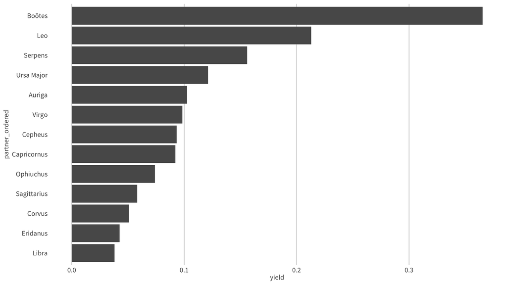

Sorted bar graph

```r
  hts_bar_sorted <-
    hts_bar %>%
    mutate(partner_ordered = fct_reorder(primepartner, yield))

  hts_bar_sorted %>%
    ggplot(aes(x = partner_ordered,
               y = yield)) +
    coord_flip() +
    geom_col() +
    si_style_xgrid()
```

This plot can be further polished by i) highlighting all partners that have yields higher than 20% ii) touching up the axes labels and iii) adding in a title and caption. If using the graphic in a presentation, adding additional annotation, such as why these two prime partners were such high performers, would be recommended as well.

To highlight the partners that have achieved beyond a given threshold, we create a new variable called color_flag. If the `yield` value is greater than 20%, then we assign the color to be scooter (`#1e87a5`) for those partners. Otherwise, the value is assigned to be grey20k (`#d1d3d4`). The `scale_fill_identity()` option is used in the `ggplot2` call to reference the fill value passed in the aesthetics portion of the code. Finally, we make use of the `scales::percent_format()` function to format that x-axis to a percentage.

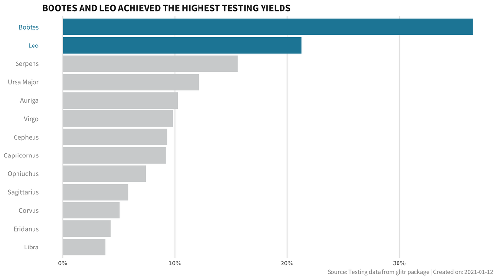

Final bar graph with SIEI colors (scooter) incorporate to highlight high performers.

```r
# Match axis label colors to top to performers
  label_colors <- if_else(sort(hts_bar_sorted$yield, decreasing = FALSE) > 0.2,
                          scooter,
                          color_caption)

  hts_bar_sorted %>%
    mutate(color_flag = if_else(yield > 0.2, scooter, grey20k)) %>%
    ggplot(aes(x = partner_ordered,
               y = yield,
               fill = color_flag)) +
    coord_flip() +
    geom_col() +
    scale_fill_identity() +
    scale_y_continuous(labels = percent_format()) +
    si_style_xgrid() +
    labs(x = NULL, y = NULL,
         title = "BOOTES AND LEO ACHIEVED THE HIGHEST TESTING YIELDS",
         caption = caption
         ) +
    theme(axis.text.y = element_text(colour = label_colors))
```